# phy_alpha_beta_bar_ven

wentao

2019年4月15日

## 分析前准备

```r
#清空内存#######
rm(list=ls())
#堆叠柱状图参数设置
#a为输出文件主名
a <- "plot_cs"
## 导入数据
ps = readRDS("./a3_DADA2_table//ps.rds")
ps
```

```
## phyloseq-class experiment-level object
## otu_table()   OTU Table:         [ 2525 taxa and 24 samples ]
## sample_data() Sample Data:       [ 24 samples by 14 sample variables ]
## tax_table()   Taxonomy Table:    [ 2525 taxa by 6 taxonomic ranks ]
## phy_tree()    Phylogenetic Tree: [ 2525 tips and 2524 internal nodes ]
```

```r
ps1 = ps
##按照最小序列数抽平
total = min(sample_sums(ps1));total
```

```
## [1] 929
```

```r
standf = function(x,t = total)round(t*(x/sum(x)))
ps11 = transform_sample_counts(ps1,standf)

path = "./phyloseq_3-1_alpha_diversity/"
dir.create(path)
mapping = as.data.frame(sample_data(ps))
mi=c("#CBD588", "#599861", "orange","#DA5724", "#508578", "#CD9BCD",
                                    "#AD6F3B", "#673770","#D14285", "#652926", "#C84248",
                                    "#8569D5", "#5E738F","#D1A33D", "#8A7C64","black")

##设置显著性比较的组别
my_comparisons <- list(c("C", "A"),c("C", "D"),c("A", "D"))
```

```r
library("phyloseq")
library("ggplot2")
library("dada2")
library("tidyverse")
library("plyr"); packageVersion("plyr")
```

```
## [1] '1.8.4'
```

```r
library("vegan")
library("ggpubr")
library("scales")

mythemealpha <- theme_bw()+
  #theme_classic()+
  # scale_color_manual(values = mi, guide = guide_legend(title = NULL))+
  # scale_fill_manual(values = mi, guide = guide_legend(title = NULL))+
  theme(

    panel.grid.major=element_blank(),
    panel.grid.minor=element_blank(),

    plot.title = element_text(vjust = -8.5,hjust = 0.1),
    axis.title.y =element_text(size = 20,face = "bold",colour = "black"),
    axis.title.x =element_text(size = 24,face = "bold",colour = "black"),
    axis.text = element_text(size = 20,face = "bold"),
    axis.text.x = element_text(colour = "black",size = 14),
    axis.text.y = element_text(colour = "black",size = 14),
    legend.text = element_text(size = 15,face = "bold"))+
  #theme(legend.position = c(0.1,0.2))+

  theme(strip.text.x = element_text(size=15, angle=0),
        strip.text.y = element_text(size=12, face="bold"),
        strip.background = element_rect(colour="blue", fill="#CCCCFF"))
```

## 导入数据 处理数据

### alpha 使用microbiomeSeq包

这里我选择了三个指标进行了分析可视化，当然有很多选择可以供我们挑选。

这个microbiomeSeq包可以加上anova检验

```r
library("microbiomeSeq")
library("ggplot2")
library("phyloseq")
physeq <- ps11
taxa_are_rows(physeq)
```

```
## [1] FALSE
```

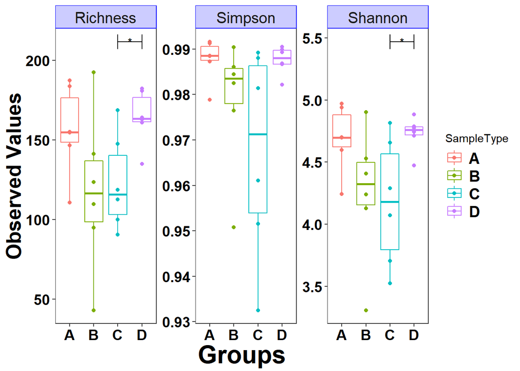

```r
p <- plot_anova_diversity(physeq, method = c("richness", "simpson", "shannon"),
    grouping_column = "SampleType", pValueCutoff = 0.05)
p = p +mythemealpha
p
```

```r
xx <- length(unique(as.data.frame(sample_data(ps1))$SampleType))
plotname = paste(path,"./a1_alpha_microbiomeSeq.pdf",sep = "")
ggsave(plotname, p, width = (4+unique(mapping$SampleType)/2)*7, height = 6,limitsize = F)
```

### 结合microbiome包和先前的出图函数计算全部alpha指标并输出

我们不挑了，全部做出来进行一个横向的比较，首先是全部指标的表格输出; 一共32种指标，由于有22中指标被集成到了alpha函数内，但是这么集成，导致中间有些指标往往计算出现错误，所以我直接贴出来源代码，方便错误寻找和排除。

```r
library(microbiome)
library(knitr)
x = ps11
index = "all"
zeroes = TRUE
tab <- NULL
index <- tolower(index)
index <- gsub("diversity_shannon", "shannon", index)
index <- gsub("richness_", "", index)
index <- unique(index)
message("Observed richness")
a <- richness(x, detection = 0, index = "observed")
a <- as.matrix(a, ncol = 1)
colnames(a) <- "observed"
tab <- cbind(tab, a)
a <- richness(x, index = "chao1")
a <- as.matrix(a, ncol = 1)
colnames(a) <- "chao1"
tab <- cbind(tab, a)

message("Diversity")
a <- diversity(x, index = gsub("diversity_", "", gsub("diversity_",
                                                        "", index)), zeroes = zeroes)
colnames(a) <- paste("diversity_", colnames(a), sep = "")
tab <- cbind(tab, a)
message("Evenness")
# a <- evenness(x, index = gsub("evenness_", "", index))
#  colnames(a) <- paste("evenness_", colnames(a), sep = "")
# tab <- cbind(tab, a)
message("Dominance")
a <- dominance(x, index = gsub("dominance_", "", index))
a <- as.matrix(a, ncol = 1)
colnames(a) <- paste("dominance_", colnames(a), sep = "")
tab <- cbind(tab, a)
message("Rarity")
#注意： "noncore_abundance"指标计算存在问题，因为数据不对称和OTU表格问题
accepted <- c("log_modulo_skewness", "low_abundance",
                "rare_abundance")
a <- rarity(x, index = accepted)
a <- as.matrix(a, ncol = 1)
colnames(a) <- paste("rarity_", colnames(a), sep = "")
tab <- cbind(tab, a)
result =  as.data.frame(tab)
dim(result)
```

```
## [1] 24 17
```

```r
 tab = result
# kable(head(tab))
#head(tab)
tab2 = estimate_richness(ps11)
# head(tab2)
mapping = as.data.frame(sample_data(ps11))

alpha = cbind(tab,tab2,mapping)
index = alpha
dim(index)
```

```
## [1] 24 40
```

```r
filename = paste(path,"./a1_alpha_index_all.csv",sep = "")
write.csv(index,filename,row.names = T,col.names = T,quote = F)
```

备注：alpha多样性指标分析表明JK1样品很可能出现错误

### plot_alpha函数进行修改，用于全部alpha多样性指标计算和出图

添加microbiome包中的20多种alpha多样性指标，并且修改误差线，淡然需要载入microbiome

```r
library("microbiome")
plot_alpha <- function (physeq, x = "samples", color = NULL, shape = NULL,
          title = NULL, scales = "free_y", nrow = 1, shsi = NULL, measures = NULL, index = "all",
          sortby = NULL)
{
  erDF1 = estimate_richness(physeq, split = TRUE, measures = measures)

  tab <- alpha(physeq, index = index)
  erDF = cbind(erDF1,tab)
  measures = colnames(erDF)
  ses = colnames(erDF)[grep("^se\\.", colnames(erDF))]
  measures = measures[!measures %in% ses]
  if (!is.null(sample_data(physeq, errorIfNULL = FALSE))) {
    DF <- data.frame(erDF, sample_data(physeq))
  }
  else {
    DF <- data.frame(erDF)
  }
  if (!"samples" %in% colnames(DF)) {
    DF$samples <- sample_names(physeq)
  }
  if (!is.null(x)) {
    if (x %in% c("sample", "samples", "sample_names", "sample.names")) {
      x <- "samples"
    }
  }
  else {
    x <- "samples"
  }
  mdf = reshape2::melt(DF, measure.vars = measures)
  mdf$se <- NA_integer_
  if (length(ses) > 0) {
    selabs = ses
    names(selabs) <- substr(selabs, 4, 100)
    substr(names(selabs), 1, 1) <- toupper(substr(names(selabs),
                                                  1, 1))
    mdf$wse <- sapply(as.character(mdf$variable), function(i,
                                                           selabs) {
      selabs[i]
    }, selabs)
    for (i in 1:nrow(mdf)) {
      if (!is.na(mdf[i, "wse"])) {
        mdf[i, "se"] <- mdf[i, (mdf[i, "wse"])]
      }
    }
    mdf <- mdf[, -which(colnames(mdf) %in% c(selabs, "wse"))]
  }
  if (!is.null(measures)) {
    if (any(measures %in% as.character(mdf$variable))) {
      mdf <- mdf[as.character(mdf$variable) %in% measures,
                 ]
    }
    else {
      warning("Argument to `measures` not supported. All alpha-diversity measures (should be) included in plot.")
    }
  }
  if (!is.null(shsi)) {
    warning("shsi no longer supported option in plot_richness. Please use `measures` instead")
  }
  if (!is.null(sortby)) {
    if (!all(sortby %in% levels(mdf$variable))) {
      warning("`sortby` argument not among `measures`. Ignored.")
    }
    if (!is.discrete(mdf[, x])) {
      warning("`sortby` argument provided, but `x` not a discrete variable. `sortby` is ignored.")
    }
    if (all(sortby %in% levels(mdf$variable)) & is.discrete(mdf[,
                                                                x])) {
      wh.sortby = which(mdf$variable %in% sortby)
      mdf[, x] <- factor(mdf[, x], levels = names(sort(tapply(X = mdf[wh.sortby,
                                                                      "value"], INDEX = mdf[wh.sortby, x], mean, na.rm = TRUE,
                                                              simplify = TRUE))))
    }
  }
  richness_map = aes_string(x = x, y = "value", colour = color,
                            shape = shape)
  p = ggplot(mdf, richness_map) + geom_point(na.rm = TRUE) +
    stat_compare_means(comparisons=my_comparisons,label = "p.signif")+
    stat_compare_means()
  if (any(!is.na(mdf[, "se"]))) {
    # p = p + geom_errorbar(aes(ymax = value + se, ymin = value -
    #                             se), width = 0.1)
  }
  p = p + theme(axis.text.x = element_text(angle = -90, vjust = 0.5,
                                           hjust = 0))
  p = p + ylab("Alpha Diversity Measure")
  p = p + facet_wrap(~variable, nrow = nrow, scales = scales)
  if (!is.null(title)) {
    p <- p + ggtitle(title)
  }
  return(p)
}
```

### 使用修改函数进行多样性计算和出图

此时plot_alpha函数可以为我们提供32中指标的可视化了。

[figure not shown]

```r
index = colnames(result)
# my_comparisons <- list(c("CK", "AB"),c("CK", "CD"),c("AB", "CD"))
p1 = plot_alpha(ps11, x="SampleType",color="SampleType",  index = index)+
  geom_boxplot(alpha=1, outlier.size=2, size=1, width=0.5,notchwidth=1) +
  geom_jitter( position=position_jitter(0.17), size=2, alpha=0.7)+
  labs(x="", y=paste("alpha diversity", sep = " "))
p1 = p1+mythemealpha+
  scale_color_manual(values = mi, guide = guide_legend(title = NULL))+
  scale_fill_manual(values = mi, guide = guide_legend(title = NULL))
p1
```

```r
plotname = paste(path,"./a1_alpha_plot_alpha_all.pdf",sep = "")
ggsave(plotname, p1, width = 50, height = 6,limitsize = F)
```

### 选择需要的指标进行出图

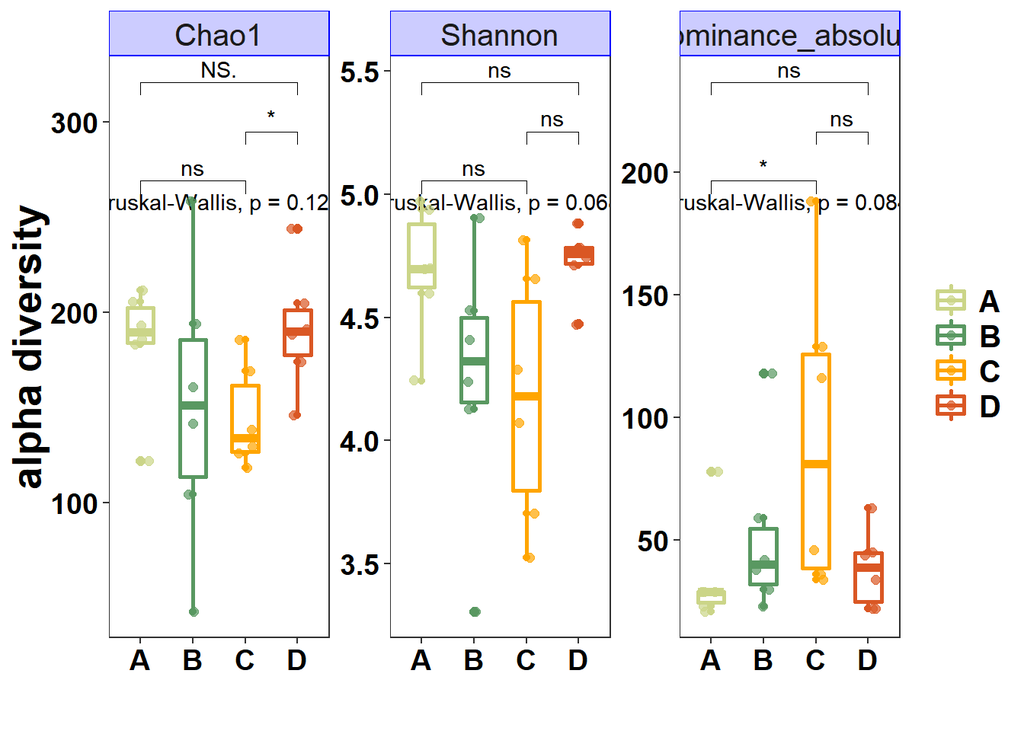

```r
# my_comparisons <- list(c("C", "A"),c("C", "D"),c("A", "D"))
p1 = plot_alpha(ps11, x="SampleType",color="SampleType", measures=c("Chao1", "Shannon"), index = 'dominance_absolute')+
  geom_boxplot(alpha=1, outlier.size=2, size=1, width=0.5,notchwidth=1) +
  geom_jitter( position=position_jitter(0.17), size=2, alpha=0.7)+
  labs(x="", y=paste("alpha diversity", sep = " "))
p1 = p1+mythemealpha+
  scale_color_manual(values = mi, guide = guide_legend(title = NULL))+
  scale_fill_manual(values = mi, guide = guide_legend(title = NULL))
p1
```

```r
plotname = paste(path,"./a1_alpha_plot_alpha.pdf",sep = "")
ggsave(plotname, p1, width = (4+unique(mapping$SampleType)/2)*7, height = 6,limitsize = F)
```

### alpha多样性的细化：支配物种，稀有物种多样性指标计算及其可视化

#### 结合支配物种多样性

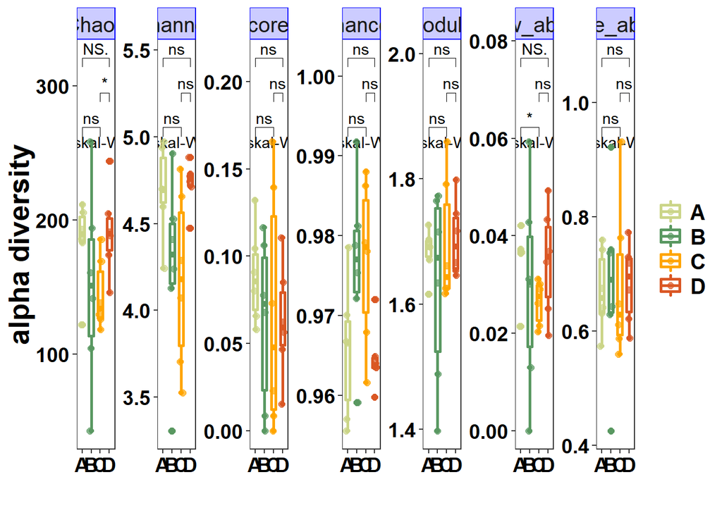

```r
domin = colnames(result)[13:19]

# my_comparisons <- list(c("C", "A"),c("C", "D"),c("A", "D"))
p1 = plot_alpha(ps11, x="SampleType",color="SampleType", measures=c("Chao1", "Shannon"), index = domin)+
  geom_boxplot(alpha=1, outlier.size=2, size=1, width=0.5,notchwidth=1) +
  geom_jitter( position=position_jitter(0.17), size=2, alpha=0.7)+
  labs(x="", y=paste("alpha diversity", sep = " "))
p1 = p1+mythemealpha+
  scale_color_manual(values = mi, guide = guide_legend(title = NULL))+
  scale_fill_manual(values = mi, guide = guide_legend(title = NULL))
p1
```

```r
plotname = paste(path,"./a1_alpha_plot_domin.pdf",sep = "")
ggsave(plotname, p1, width = 20, height = 6,limitsize = F)
```

#### 结合稀有物种多样性

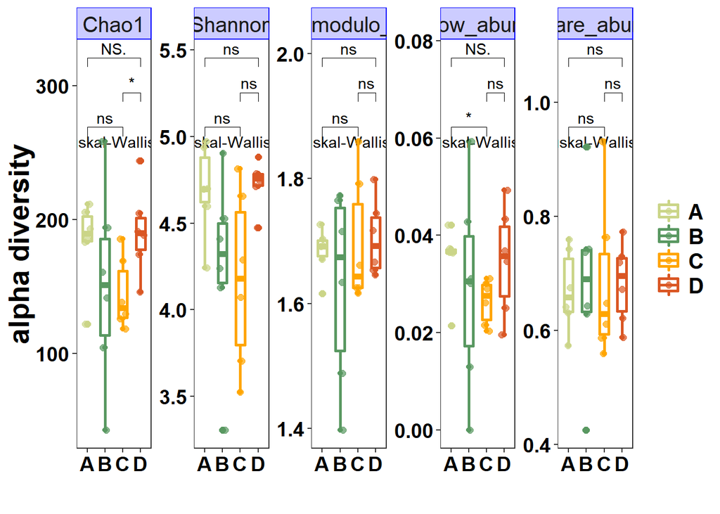

```r
# rare = colnames(result)[20:22]

p2 = plot_alpha(ps11, x="SampleType",color="SampleType", measures=c("Chao1", "Shannon"), index = c("rarity_log_modulo_skewness","rarity_low_abundance","rarity_rare_abundance"))+
  geom_boxplot(alpha=1, outlier.size=2, size=1, width=0.5,notchwidth=1) +
  geom_jitter( position=position_jitter(0.17), size=2, alpha=0.7)+
  labs(x="", y=paste("alpha diversity", sep = " "))
p2 = p2+mythemealpha+
  scale_color_manual(values = mi, guide = guide_legend(title = NULL))+
  scale_fill_manual(values = mi, guide = guide_legend(title = NULL))
p2
```

```r
plotname = paste(path,"./a1_alpha_plot_rare.pdf",sep = "")
ggsave(plotname, p2, width = 12, height = 6,limitsize = F)
```